# Florida Water Level

Blake Tindol

7/18/2021

## Sea Level Raise Analysis

The purpose of this analysis was to look at the rate of sea level raise in florida. I wanted to see if it is worth it to buy a home in florida, or if flooding will destroy the property in my life time and if so when.

This analysis was done using weather station data from different stations spread across Florida evenly using the RNOAA API in R. To copy this analysis you will have to get your own personal API key for NOAA at # API Key http://www.ncdc.noaa.gov/cdo-web/token.

To get the florida station codes go to my github at My github. https://github.com/btindol178/Sea-Level-Raise-Analysis-.

```r
# API Key @  http://www.ncdc.noaa.gov/cdo-web/token
options(noaakey = "Your API Key Here")

# small list of stations evenly spaced around states boarder on all sides
# we want the station id for RNOAA API calls
florida_stations <- read.csv("florida_stations.csv");colnames(florida_stations)[1] <- "ID"

# Bring in leaflet points for plot
mappoints <- read.csv("mappoints.csv")

# pick one station for API Testing in florida
station1 <- florida_stations$ID[1]

# read in water level data for all of the different stations
temp <- read.csv("florida_water_levels_in_feet_final.csv");temp <- temp[-c(1)]

kable(florida_stations)
```

| ID | City |
| --- | --- |
| 8725110 | Naples, Gulf of Mexico, FL |
| 8725520 | Fort Myers, FL |
| 8723214 | Virginia Key, Biscayne Bay, FL |
| 8722956 | South Port Everglades, FL |
| 8722670 | Lake Worth Pier, Atlantic Ocean, FL |
| 8726384 | Port Manatee, FL |
| 8726520 | St. Petersburg, Tampa Bay, FL |
| 8721604 | Trident Pier, Port Canaveral, FL |
| 8727520 | Cedar Key, FLÂ |
| 8720218 | MayportÂ |
| 8728690 | Apalachicola |
| 8729840 | Pensacola |

## Locations of the weather stations that feed the NOAA API.we are going to pickevenly spaced stations around state

```r
leaflet(data = mappoints) %>%
  addTiles() %>%
  addCircles(lng = mappoints$lonz,
             lat = mappoints$latz,
             popup = mappoints$stationname) %>%
  clearBounds()
```

[interactive chart not shown]

## Example API call from the API

```r
# get water level
station1_pull <-coops_search(station_name = station1, begin_date = 20140927,
             end_date = 20140928, product = "water_level", datum = "stnd")
# Make dataframe
station1_pull <- data.frame(station1_pull);colnames(station1_pull)<- c("ID","Station Name", "lat","lon","date time","water level (ft)","standard dev","other data","other data2")

kable(head(station1_pull[c(1:7)]))
```

| ID | Station Name | lat | lon | date time | water level (ft) | standard dev |
| --- | --- | --- | --- | --- | --- | --- |
| 8725110 | Naples, Gulf of Mexico | 26.1317 | -81.8075 | 2014-09-27 00:00:00 | 1.164 | 0.023 |
| 8725110 | Naples, Gulf of Mexico | 26.1317 | -81.8075 | 2014-09-27 00:06:00 | 1.162 | 0.021 |
| 8725110 | Naples, Gulf of Mexico | 26.1317 | -81.8075 | 2014-09-27 00:12:00 | 1.157 | 0.023 |
| 8725110 | Naples, Gulf of Mexico | 26.1317 | -81.8075 | 2014-09-27 00:18:00 | 1.152 | 0.022 |
| 8725110 | Naples, Gulf of Mexico | 26.1317 | -81.8075 | 2014-09-27 00:24:00 | 1.153 | 0.023 |
| 8725110 | Naples, Gulf of Mexico | 26.1317 | -81.8075 | 2014-09-27 00:30:00 | 1.160 | 0.021 |

## Now we need to get two vectors to programatically enter the date range for API calls

```r
# Get a time range for the next 130 months from 2010/01/01
datevar <- seq(as.Date("2010/01/01"), by = "month", length.out = 130)

# Get a time range for the next 130 months from 2010/02/01
datevar2 <- seq(as.Date("2010/02/01"), by = "month", length.out = 130)

# clean up columns for API Call format
datedf <- data.frame(start=datevar,end=datevar2)
datedf$start <- gsub("-","",datedf$start)
datedf$end <- gsub("-","",datedf$end)
datedf$start <- as.numeric(datedf$start)
datedf$end <- as.numeric(datedf$end)
kable(head(datedf))
```

| start | end |
| --- | --- |
| 20100101 | 20100201 |
| 20100201 | 20100301 |
| 20100301 | 20100401 |
| 20100401 | 20100501 |
| 20100501 | 20100601 |
| 20100601 | 20100701 |

## Now we will programmatically get all of the stations data from 2010 to 2020

Steps:  
1) Outer loop goes through all stations  
2) Inner loop goes through each row in datedf dataframe which has start and end date  
3) API call  
4) Aggregate the data by mean daily value for water level and bind to empty dataframe  
I left this out because it takes to long to do again if you want to fully emulate the analyss go to R file in github

```r
# temp <-NULL
# for(j in 1:nrow(florida_stations)){
#   for(i in 1:nrow(datedf)){
#     #print(datedf$start[i])
#     tempdate <- NULL
#     startz <- NULL
#     endz <- NULL
#     tryCatch({
#       stationz <- florida_stations$ï..ID[j]
#       startZ <-datedf$start[i]
#       endZ <-datedf$end[i]
#
#       tempdate <- coops_search(station_name = stationz, begin_date = startZ,end_date = endZ, product = "water_level", datum = "stnd",time_zone = "lst")
#       tempdate2 <- data.frame(tempdate[['data']]) # make list dataframe
#       tempdate2$stationname <- tempdate$metadata$name # make name the column
#       tempdate2$lat <- tempdate$metadata$lat
#       tempdate2$lon <- tempdate$metadata$lon
#       tempdate2$day <- day(tempdate2$t)
#       tempdate2$year <- year(tempdate2$t)
#       tempdate2$month <- month(tempdate2$t)
#
#       # group by year month and day and get the average water level for that day before appending
#       tempdate3 <- tempdate2 %>%
#         group_by(year,month,day)%>%
#         summarise(water_level = mean(v,na.rm = TRUE),stationname=unique(stationname),lat=unique(lat),lon=unique(lon))
#
#       temp <- rbind(temp,tempdate3)
#     }, error=function(e){cat("ERROR :",conditionMessage(e), "\n")})
#     print(i)
#   }
# }
#temp$date <- paste(temp$year,temp$month,temp$day,sep="-"); temp$date <- as.Date(temp$date)


#write.csv(temp,file="florida_water_levels_in_feet.csv")
```

## Perform some summary statistics on the different stations (All Years)

- Min, max, standard deviation and mean water levels in feet.

```r
temp_sum2 <- temp %>%
  group_by(stationname) %>%
  summarise(max_level = round(max(water_level,na.rm=TRUE),digits=3),min_level = round(min(water_level,na.rm=TRUE),digits = 3),std_level = round(sd(water_level,na.rm=TRUE),digits=3),mean_level = round(mean(water_level,na.rm=TRUE),digits=3))

kable(temp_sum2)
```

| stationname | max_level | min_level | std_level | mean_level |
| --- | --- | --- | --- | --- |
| Apalachicola | 3.049 | 1.007 | 0.156 | 1.683 |
| Cedar Key | 2.265 | 0.187 | 0.171 | 1.274 |
| Fort Myers | 2.424 | 1.022 | 0.135 | 1.627 |
| Lake Worth Pier, Atlantic Ocean | 10.208 | 9.380 | 0.124 | 9.699 |
| Mayport (Bar Pilots Dock) | 4.508 | 3.058 | 0.168 | 3.590 |
| Naples, Gulf of Mexico | 1.762 | 0.825 | 0.115 | 1.260 |
| Pensacola | 4.136 | 2.335 | 0.149 | 2.876 |
| Port Manatee | 1.238 | -0.160 | 0.128 | 0.515 |
| South Port Everglades | 8.301 | 7.590 | 0.128 | 7.895 |
| St. Petersburg, Tampa Bay | 2.317 | 0.617 | 0.133 | 1.493 |
| Trident Pier, Port Canaveral | 6.802 | 5.783 | 0.147 | 6.141 |
| Virginia Key, Biscayne Bay | 4.256 | 3.204 | 0.117 | 3.530 |

## Perform some summary statistics on the different stations by year

- Here we get the CAGR (annual growth rate) for the station in St. Petersburg, Tampa Bay.
- CAGR is in inches so here its about .6% of an inch less than 1%

```r
temp_sum_year2 <- temp %>%
  group_by(stationname,year) %>%
  summarise(max_level = round(max(water_level,na.rm=TRUE),digits=3),min_level = round(min(water_level,na.rm=TRUE),digits = 3),std_level = round(sd(water_level,na.rm=TRUE),digits=3),mean_level = round(mean(water_level,na.rm=TRUE),digits=3)) %>%
  mutate(firstz = dplyr::first(mean_level),lastz = dplyr::last(mean_level),nrows = n(),cagr_level= round(((lastz/firstz)^(1/nrows)-1),digits=4))

kable(temp_sum_year2[temp_sum_year2$stationname == "St. Petersburg, Tampa Bay",c(2:10)])
```

| year | max_level | min_level | std_level | mean_level | firstz | lastz | nrows | cagr_level |
| --- | --- | --- | --- | --- | --- | --- | --- | --- |
| 2010 | 1.763 | 1.002 | 0.133 | 1.439 | 1.439 | 1.542 | 11 | 0.0063 |
| 2011 | 1.859 | 0.948 | 0.127 | 1.433 | 1.439 | 1.542 | 11 | 0.0063 |
| 2012 | 2.317 | 0.985 | 0.135 | 1.503 | 1.439 | 1.542 | 11 | 0.0063 |
| 2013 | 1.810 | 1.025 | 0.122 | 1.472 | 1.439 | 1.542 | 11 | 0.0063 |
| 2014 | 1.767 | 0.989 | 0.109 | 1.487 | 1.439 | 1.542 | 11 | 0.0063 |
| 2015 | 1.891 | 1.083 | 0.130 | 1.507 | 1.439 | 1.542 | 11 | 0.0063 |
| 2016 | 2.109 | 1.128 | 0.122 | 1.513 | 1.439 | 1.542 | 11 | 0.0063 |
| 2017 | 1.987 | 0.617 | 0.133 | 1.493 | 1.439 | 1.542 | 11 | 0.0063 |
| 2018 | 2.055 | 0.937 | 0.135 | 1.493 | 1.439 | 1.542 | 11 | 0.0063 |
| 2019 | 2.076 | 1.072 | 0.131 | 1.549 | 1.439 | 1.542 | 11 | 0.0063 |
| 2020 | 1.862 | 1.078 | 0.133 | 1.542 | 1.439 | 1.542 | 11 | 0.0063 |

## Lets the time series for each station by year

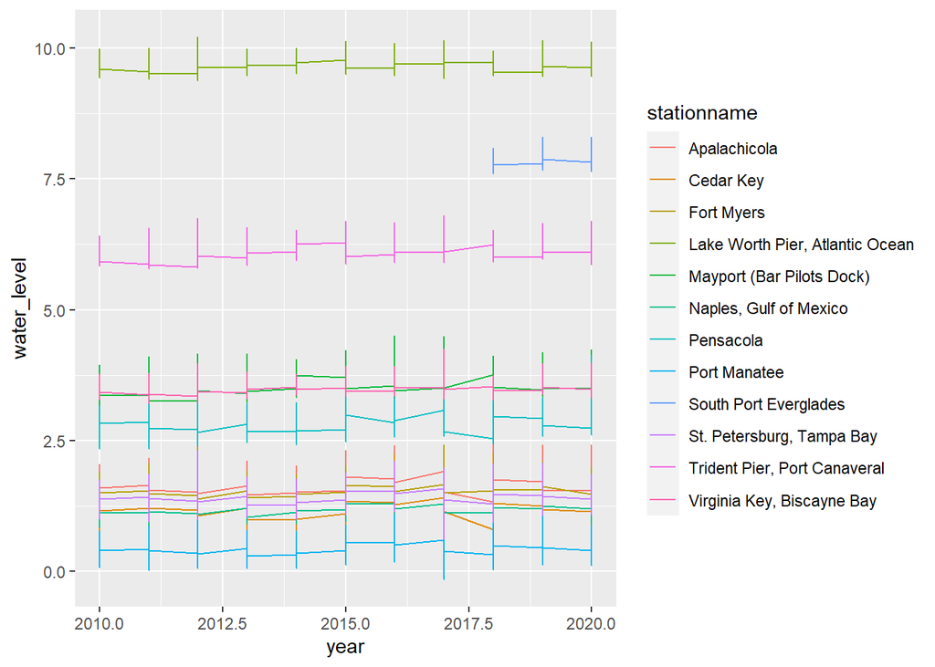

```r
ggplot(temp,aes(x=year,y=water_level,colour=stationname,group=stationname)) + geom_line()
```

## I did this analysis to see if the ocean raises at an exponential rate what year and at what level would the water level be at for different years.

- I will start at 2010 and go for the next 100 years. We will only look at Naples for example.
- I did collect data for all stations as well.

```r
uniquestation <- unique(temp$stationname)

external_station <- NULL
for(i in 1:length(uniquestation)) {
  tempzt <- NULL
  temp_sum2 <- NULL
  temp_sum_year2 <- NULL

  tempzt <- temp[temp$stationname == uniquestation[i],];#tempzt <- data.frame(tempzt)

  # get summary stats
  temp_sum2 <- tempzt %>%
    group_by(stationname,year) %>%
    summarise(max_level = round(max(water_level,na.rm=TRUE),digits=3),min_level = round(min(water_level,na.rm=TRUE),digits = 3),std_level = round(sd(water_level,na.rm=TRUE),digits=3),mean_level = round(mean(water_level,na.rm=TRUE),digits=3),.groups = 'drop')

  # get cagr for rate..
  temp_sum_year2 <- tempzt %>%
    group_by(stationname,year) %>%
    summarise(max_level = round(max(water_level,na.rm=TRUE),digits=3),min_level = round(min(water_level,na.rm=TRUE),digits = 3),std_level = round(sd(water_level,na.rm=TRUE),digits=3),mean_level = round(mean(water_level,na.rm=TRUE),digits=3),.groups = 'drop') %>%
    mutate(firstz = dplyr::first(mean_level),lastz = dplyr::last(mean_level),nrows = n(),cagr_level= round(((lastz/firstz)^(1/nrows)-1),digits=4))


  # make empty vectors for the years that we will project out to
  years <- seq(from=0, to=100, by=1) # we will make an empty vector of 0's for 100 years so 2121
  nyears <- 100
  N <- numeric(nyears+1) # empty vector of 100 0's

  # make initial value (aka last years mean value ) ( last years mean value of water level for the station)
  N0 <- last(temp_sum2$mean_level)

  # rate of growth by year
  r <- unique(temp_sum_year2$cagr_level)

  # lambda is 1+r
  lambda <- 1+r

  # Run the simulation!! of exponentioal growth in the next 100years
  N[1] <- N0
  lambda <- 1 + r
  for (i in 2:(nyears+1)){
    N[i] <- lambda*N[i-1]

  }

  # put date column for graph
  datez <- seq(as.Date("2010/01/01"), by = "year", length.out = 101)
  datedfz <- data.frame(date = datez, water_level=N)
  datedfz$multiplyer <- unique(temp_sum_year2$cagr_level) #.0083
  datedfz$cumsum <- cumsum(datedfz$multiplyer)
  datedfz$water_level_doubled_rate<- datedfz$water_level + datedfz$cumsum       # This is a vector of the water level in feet for the next 100 years at an exponential rate
  datedfz$station <- unique(temp_sum2$stationname)

  external_station <- rbind(external_station,datedfz)

}

kable(head(external_station[c(1,2,6)],n=100))
```

| date | water_level | station |
| --- | --- | --- |
| 2010-01-01 | 1.313000 | Naples, Gulf of Mexico |
| 2011-01-01 | 1.323898 | Naples, Gulf of Mexico |
| 2012-01-01 | 1.334886 | Naples, Gulf of Mexico |
| 2013-01-01 | 1.345966 | Naples, Gulf of Mexico |
| 2014-01-01 | 1.357137 | Naples, Gulf of Mexico |
| 2015-01-01 | 1.368402 | Naples, Gulf of Mexico |
| 2016-01-01 | 1.379759 | Naples, Gulf of Mexico |
| 2017-01-01 | 1.391211 | Naples, Gulf of Mexico |
| 2018-01-01 | 1.402758 | Naples, Gulf of Mexico |
| 2019-01-01 | 1.414401 | Naples, Gulf of Mexico |
| 2020-01-01 | 1.426141 | Naples, Gulf of Mexico |
| 2021-01-01 | 1.437978 | Naples, Gulf of Mexico |
| 2022-01-01 | 1.449913 | Naples, Gulf of Mexico |
| 2023-01-01 | 1.461947 | Naples, Gulf of Mexico |
| 2024-01-01 | 1.474081 | Naples, Gulf of Mexico |
| 2025-01-01 | 1.486316 | Naples, Gulf of Mexico |
| 2026-01-01 | 1.498653 | Naples, Gulf of Mexico |
| 2027-01-01 | 1.511092 | Naples, Gulf of Mexico |
| 2028-01-01 | 1.523634 | Naples, Gulf of Mexico |
| 2029-01-01 | 1.536280 | Naples, Gulf of Mexico |
| 2030-01-01 | 1.549031 | Naples, Gulf of Mexico |
| 2031-01-01 | 1.561888 | Naples, Gulf of Mexico |
| 2032-01-01 | 1.574852 | Naples, Gulf of Mexico |
| 2033-01-01 | 1.587923 | Naples, Gulf of Mexico |
| 2034-01-01 | 1.601103 | Naples, Gulf of Mexico |
| 2035-01-01 | 1.614392 | Naples, Gulf of Mexico |
| 2036-01-01 | 1.627791 | Naples, Gulf of Mexico |
| 2037-01-01 | 1.641302 | Naples, Gulf of Mexico |
| 2038-01-01 | 1.654925 | Naples, Gulf of Mexico |
| 2039-01-01 | 1.668661 | Naples, Gulf of Mexico |

[output cut: 70 more lines]

## Now lets look at only specific years for each station and see the difference from first year 2010

```r
wl_2010 = external_station[external_station$date =="2010-01-01",c(1,2,6)];colnames(wl_2010)[2] <- "water_level_2010"
wl_2030 = external_station[external_station$date =="2030-01-01",c(1,2,6)];colnames(wl_2030)[2] <- "water_level_2030"
wl_2050 = external_station[external_station$date =="2050-01-01",c(1,2,6)];colnames(wl_2050)[2] <- "water_level_2050"
wl_2075 = external_station[external_station$date =="2075-01-01",c(1,2,6)];colnames(wl_2075)[2] <- "water_level_2075"
wl_2110 =external_station[external_station$date =="2110-01-01",c(1,2,6)];colnames(wl_2110)[2] <- "water_level_2110"

# join all of the years
merge1 <- merge(wl_2010,wl_2030,by=c("station"),all.x=TRUE)
merge2 <- merge(merge1,wl_2050,by=c("station"),all.x=TRUE)
merge3 <- merge(merge2,wl_2075,by=c("station"),all.x=TRUE)
merge4 <- merge(merge3,wl_2110,by=c("station"),all.x=TRUE)
merge_final <- merge4[c(1,3,5,7,9,11)];
merge_final$feet_increase_30_years <- merge_final$water_level_2030-merge_final$water_level_2010
merge_final$feet_increase_50_years <- merge_final$water_level_2050-merge_final$water_level_2010
merge_final$feet_increase_70_years <- merge_final$water_level_2075-merge_final$water_level_2010
merge_final$feet_increase_100_years <- merge_final$water_level_2110-merge_final$water_level_2010

kable(merge_final[,c(1,7,8,9,10)])
```

| station | feet_increase_30_years | feet_increase_50_years | feet_increase_70_years | feet_increase_100_years |
| --- | --- | --- | --- | --- |
| Apalachicola | 0.2310590 | 0.4925214 | 0.8682479 | 1.5020355 |
| Cedar Key | 0.2505052 | 0.5478059 | 0.9987067 | 1.8163677 |
| Fort Myers | 0.1855538 | 0.3917989 | 0.6822414 | 1.1590695 |
| Lake Worth Pier, Atlantic Ocean | 0.0977736 | 0.1965296 | 0.3213712 | 0.4987912 |
| Mayport (Bar Pilots Dock) | 0.2321322 | 0.4790885 | 0.8100781 | 1.3186744 |
| Naples, Gulf of Mexico | 0.2360309 | 0.5144917 | 0.9339820 | 1.6878304 |
| Pensacola | 0.2918074 | 0.6123047 | 1.0575947 | 1.7755570 |
| Port Manatee | 0.1879352 | 0.4405583 | 0.8819206 | 1.8501715 |
| South Port Everglades | 0.4379986 | 0.9002658 | 1.5142830 | 2.4465020 |
| St. Petersburg, Tampa Bay | 0.2063719 | 0.4403634 | 0.7773703 | 1.3475595 |
| Trident Pier, Port Canaveral | 0.2262526 | 0.4607910 | 0.7660795 | 1.2172122 |
| Virginia Key, Biscayne Bay | 0.2133420 | 0.4394047 | 0.7410315 | 1.2017311 |

## Stacked Bar Chart

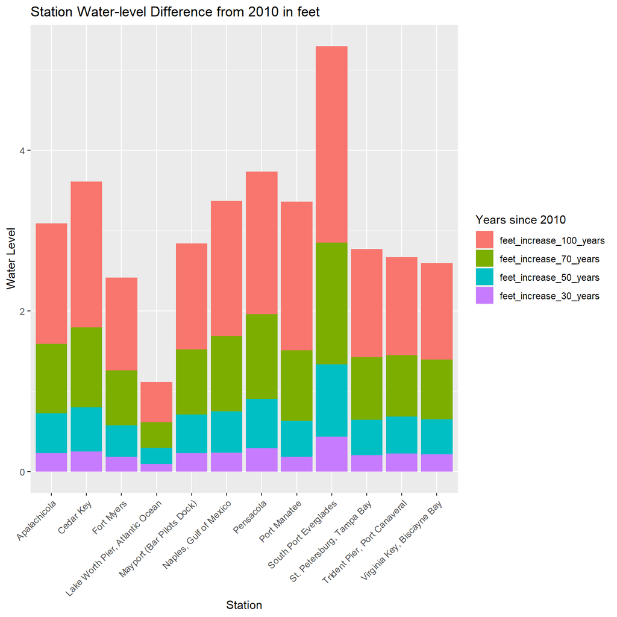

```r
long_DF <- merge_final %>% gather(water_level_class, water_level_feet, feet_increase_30_years:feet_increase_100_years)


p<-ggplot(data=long_DF, aes(x=station, y=water_level_feet,fill=factor(water_level_class, levels=c("feet_increase_100_years","feet_increase_70_years","feet_increase_50_years","feet_increase_30_years")))) +
  geom_bar(stat="identity")+ theme(axis.text.x = element_text(angle = 45, vjust = 1, hjust=1))+ labs(title= "Station Water-level Difference from 2010 in feet",y="Water Level", x = "Station")+ guides(fill=guide_legend(title="Years since 2010"))


p
```

## Clustered Bar Chart

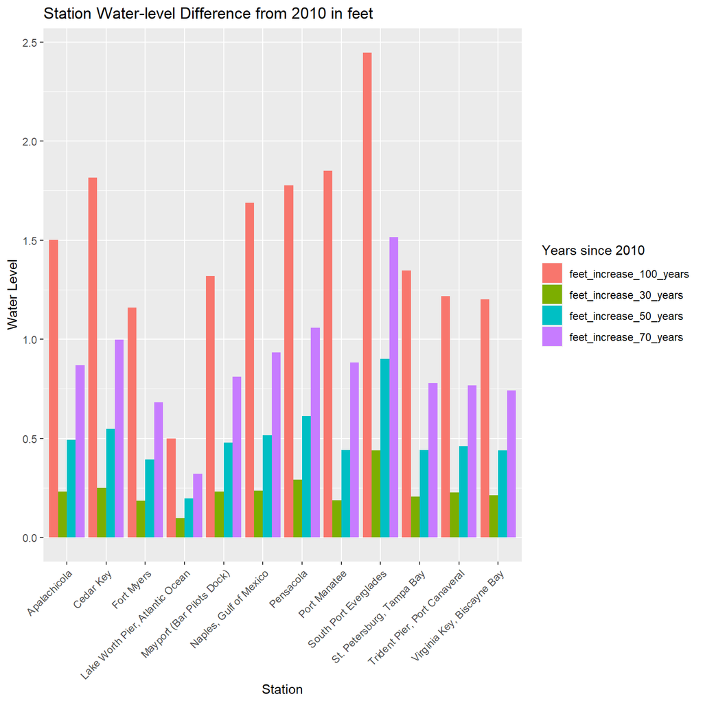

```r
d <- ggplot(long_DF, aes(fill=water_level_class, y=water_level_feet, x=station)) +
  geom_bar(position="dodge", stat="identity")+ theme(axis.text.x = element_text(angle = 45, vjust = 1, hjust=1))+ labs(title= "Station Water-level Difference from 2010 in feet",y="Water Level", x = "Station")+ guides(fill=guide_legend(title="Years since 2010"))


d
```

## In 100 years the maximum water level increase for a station is 2.5 ft.

- Lets see what that looks like at NOAA’S sea level simulator at  
  https://coast.noaa.gov/slr/#/layer/slr/2/-9220234.345848428/3243916.8651185175/7/satellite/none/0.8/2050/interHigh/midAccretion

[figure not shown]

## I really like St. Petersburg FL lets see 1 foot here.

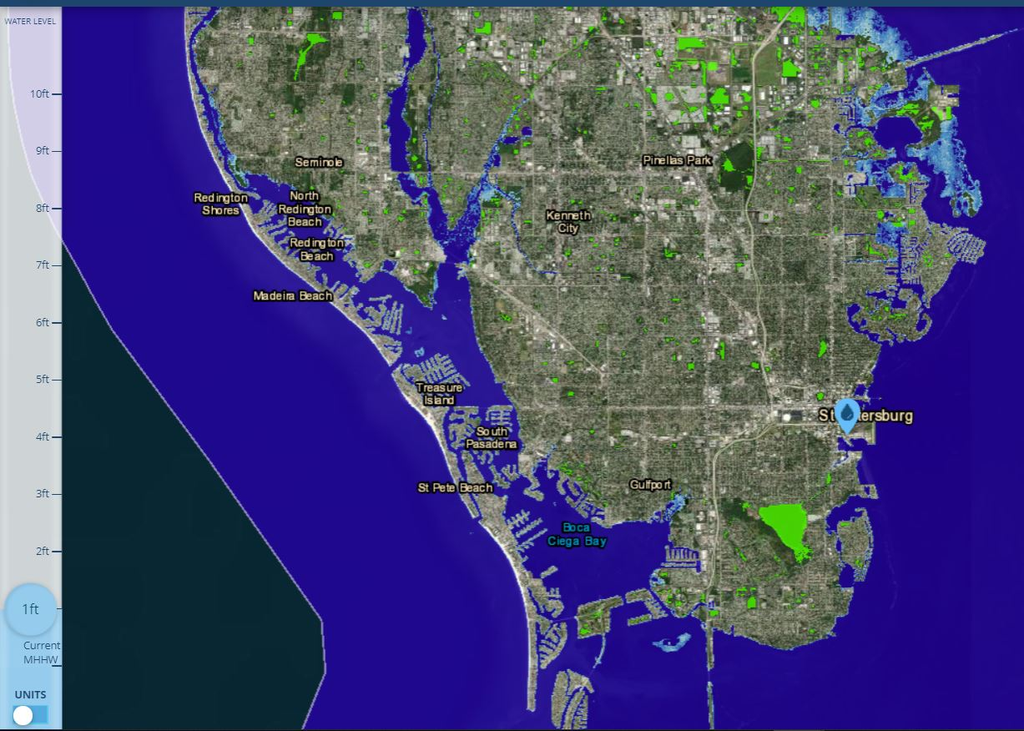

## No real impact it looks like now lets see two feet.

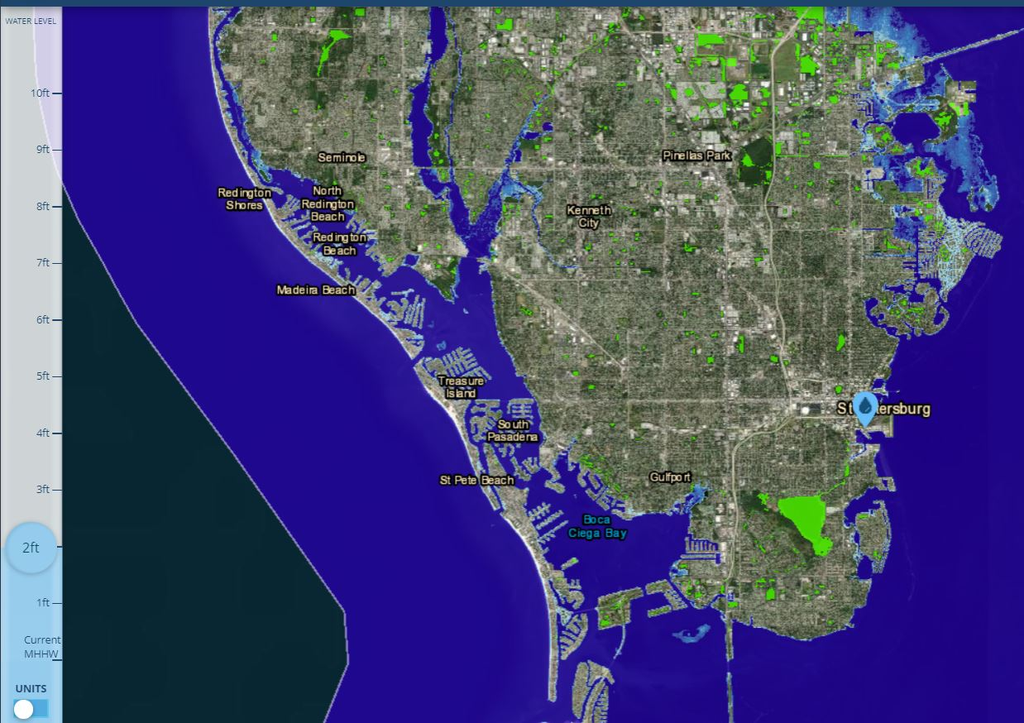

## Summary

- In analysis to decide if i should move to florida or not based on how fast the sea level increases, i choose to move down. This is a simple API EDA and is not perfect but can be a guide when trying to explore climate information.
- Considerations:
  - This was based on CAGR’S of 10 years of data.
  - This does not take into account natural weather disasters such as hurricanes or earthquakes.